# Bellabeat

Marcos Javier García Barrios

2023-02-07

## **Introduction**

The Bellabeat’s co-founder, Sršen, is aware that the analysis of Bellabeat’s available consumption data should reveal new growth opportunities for the company. She asked the marketing’s computational data analysis team to concentrate on one Bellabeat’s product and analyze the usage data of the smart devices in order to know how people actually use their smart devices. Then, with these insights, she would like to receive some high-level recommendations on how these tendencies could be utilized in Bellabeat’s marketing strategies.

#### *Stakeholders:*

- Urška Sršen: Co-founder and Bellabeat’s Creative Director
- Sando Mur: Co-founder and Mathematician, key Bellabeat’s executive team member.

Sršen requested to analyze smart device usage data to determine how consumers are using their smart devices that are not Bellabeat’s. Then, she wants a single Bellabeat’s product to be selected to apply the analysis insights to a presentation.

#### *Business Task:*

The main objective of this project is to know and study the habits of use of smart devices like Fitness Tracker Data of the company FitBit , different from those of Bellabeat, by users. This project will reveal the(s) trend(s) in these usage habits. Once these trends have been identified, make the findings known and develop a recommendation for the main stakeholders of this project (the co-founders of Bellabeat: Urška Sršen and Sando Mur), in relation to one of the different Bellabeat products that can take advantage of the area of opportunity that exists in the habits of use of users, so that in this way a marketing strategy can be formulated and implemented successfully.

## **Data Prepare**

Prior the clean and preparation, a data validation was conducted. The data source is the outreach/community platform for Data Analysts: “Kaggle”. This is a data set generated by responses in a survey distributed via Amazon Mechanical Turk between 03.12.2016-05.12.2016; manipulation and public use under the corresponding permits and citations. Thirty eligible Fitbit users consented to the submission of personal tracking data, including minute-level results for physical activity, heart rate and sleep control. The variation between results represents the use of different types of Fitbit trackers and individual tracking behaviors/preferences.

For more detailed information about the data validation, please consult the [“Bellabeat_Prepare_MJGB”](https://docs.google.com/document/d/1AQujeIfU9bvYr88bJZirVxVO2nVcXG1gRrp13wEb5eg/edit?usp=sharing&resourcekey=0-tFB6Fu3uu99qBQjwWphvWg) report.

### Setting up

To perform the data cleaning, we use the following packages:

```r
library(tidyverse)
library(dplyr)
library(dbplyr)
library(knitr)
library(readr)
library(data.table)
```

As dataset, we will used the following .csv files from the original source:

- dailyActivity_merged;
- heartrate_seconds_merged;
- minuteIntensitiesNarrow_merged;
- minuteMETsNarrow_merged;
- minuteSleep_merged;
- sleepDay_merged

*IMPORTANT: the current data has only 33 users activities from 4/12/2016 to 5/11/2016. This is not enough to represent the entire group of users whose ways of exercises may differ from season to season. Nevertheless, methods used in the analysis can be carried over straight to larger amount of data when available.*

### Data Clean

#### **Formatting dates**

The dates provided in this dataset are too complex to be worked in a SLQ environment. So we use R to convert them into a format that is more suitable for the later analysis.

**The heartrate_seconds_merged was modified before everything else in order to match the units of the other data sets, went from seconds to minutes; so the new data set is minutes_heartrate.

Setting work directory:

```r
setwd("D:/JavviGabba/Documents/Data Analytics/Bellabeat/Data")
```

*Specifically we format the original date such as 4/12/2016 3:00:00 PM as 2016-04-12 15:00:00.*

```r
dailyActivity_merged <- read_csv("D:/JavviGabba/Documents/Data Analytics/Bellabeat/Data/dailyActivity_merged.csv") %>%
  mutate(ActivityDate = as.Date(ActivityDate, format = "%m/%d/%Y"))

minutes_heartrate <- read_csv("D:/JavviGabba/Documents/Data Analytics/Bellabeat/Data/minutes_heartrate.csv") %>%
  mutate(time = strftime(as.POSIXlt(time, format = "%m/%d/%Y %I:%M:%S %p")))

minuteIntensities_merged <- read_csv("D:/JavviGabba/Documents/Data Analytics/Bellabeat/Data/minuteIntensitiesNarrow_merged.csv") %>%
  mutate(ActivityMinute = strftime(as.POSIXlt(ActivityMinute, format = "%m/%d/%Y %I:%M:%S %p")))

minuteMETs_merged <- read_csv("D:/JavviGabba/Documents/Data Analytics/Bellabeat/Data/minuteMETsNarrow_merged.csv") %>%
  mutate(ActivityMinute = strftime(as.POSIXlt(ActivityMinute, format = "%m/%d/%Y %I:%M:%S %p")))

minuteSleep_merged <- read_csv("D:/JavviGabba/Documents/Data Analytics/Bellabeat/Data/minuteSleep_merged.csv") %>%
  mutate(date = strftime(as.POSIXlt(date, format = "%m/%d/%Y %I:%M:%S %p")))

sleepDay_merged <- read_csv("D:/JavviGabba/Documents/Data Analytics/Bellabeat/Data/sleepDay_merged.csv") %>%
  mutate(SleepDay = strftime(as.POSIXlt(SleepDay, format = "%m/%d/%Y %I:%M:%S %p")))
```

We want to see a preview of each data set that we just formatted.

```r
head(dailyActivity_merged)
```

```
## # A tibble: 6 × 15
##           Id ActivityDate TotalSteps TotalDistance TrackerDistance
##        <dbl> <date>            <dbl>         <dbl>           <dbl>
## 1 1503960366 2016-04-12        13162          8.5             8.5
## 2 1503960366 2016-04-13        10735          6.97            6.97
## 3 1503960366 2016-04-14        10460          6.74            6.74
## 4 1503960366 2016-04-15         9762          6.28            6.28
## 5 1503960366 2016-04-16        12669          8.16            8.16
## 6 1503960366 2016-04-17         9705          6.48            6.48
## # ℹ 10 more variables: LoggedActivitiesDistance <dbl>,
## #   VeryActiveDistance <dbl>, ModeratelyActiveDistance <dbl>,
## #   LightActiveDistance <dbl>, SedentaryActiveDistance <dbl>,
## #   VeryActiveMinutes <dbl>, FairlyActiveMinutes <dbl>,
## #   LightlyActiveMinutes <dbl>, SedentaryMinutes <dbl>, Calories <dbl>
```

```r
head(minutes_heartrate)
```

```
## # A tibble: 6 × 3
##   time                        Id Value
##   <chr>                    <dbl> <dbl>
## 1 2016-04-12 01:00:00 2022484408    66
## 2 2016-04-12 01:01:00 2022484408    66
## 3 2016-04-12 01:02:00 2022484408    68
## 4 2016-04-12 01:03:00 2022484408    73
## 5 2016-04-12 01:04:00 2022484408    80
## 6 2016-04-12 01:05:00 2022484408    75
```

```r
head(minuteIntensities_merged)
```

```
## # A tibble: 6 × 3
##           Id ActivityMinute      Intensity
##        <dbl> <chr>                   <dbl>
## 1 1503960366 2016-04-12 00:00:00         0
## 2 1503960366 2016-04-12 00:01:00         0
## 3 1503960366 2016-04-12 00:02:00         0
## 4 1503960366 2016-04-12 00:03:00         0
## 5 1503960366 2016-04-12 00:04:00         0
## 6 1503960366 2016-04-12 00:05:00         0
```

```r
head(minuteMETs_merged)
```

```
## # A tibble: 6 × 3
##           Id ActivityMinute       METs
##        <dbl> <chr>               <dbl>
## 1 1503960366 2016-04-12 00:00:00    10
## 2 1503960366 2016-04-12 00:01:00    10
## 3 1503960366 2016-04-12 00:02:00    10
## 4 1503960366 2016-04-12 00:03:00    10
## 5 1503960366 2016-04-12 00:04:00    10
## 6 1503960366 2016-04-12 00:05:00    12
```

```r
head(minuteSleep_merged)
```

```
## # A tibble: 6 × 4
##           Id date                value       logId
##        <dbl> <chr>               <dbl>       <dbl>
## 1 1503960366 2016-04-12 02:47:30     3 11380564589
## 2 1503960366 2016-04-12 02:48:30     2 11380564589
## 3 1503960366 2016-04-12 02:49:30     1 11380564589
## 4 1503960366 2016-04-12 02:50:30     1 11380564589
## 5 1503960366 2016-04-12 02:51:30     1 11380564589
## 6 1503960366 2016-04-12 02:52:30     1 11380564589
```

```r
head(sleepDay_merged)
```

```
## # A tibble: 6 × 5
##           Id SleepDay   TotalSleepRecords TotalMinutesAsleep TotalTimeInBed
##        <dbl> <chr>                  <dbl>              <dbl>          <dbl>
## 1 1503960366 2016-04-12                 1                327            346
## 2 1503960366 2016-04-13                 2                384            407
## 3 1503960366 2016-04-15                 1                412            442
## 4 1503960366 2016-04-16                 2                340            367
## 5 1503960366 2016-04-17                 1                700            712
## 6 1503960366 2016-04-19                 1                304            320
```

#### **Remove duplicates**

We use the *duplicated function* to perform a check-up o for duplicates.

```r
nrow(dailyActivity_merged[duplicated(dailyActivity_merged),])
## [1] 0
nrow(minutes_heartrate[duplicated(minutes_heartrate),])
## [1] 0
nrow(minuteIntensities_merged[duplicated(minuteIntensities_merged),])
## [1] 0
nrow(minuteMETs_merged[duplicated(minuteMETs_merged),])
## [1] 0
nrow(minuteSleep_merged[duplicated(minuteSleep_merged),])
## [1] 543
nrow(sleepDay_merged[duplicated(sleepDay_merged),])
## [1] 3
```

There are 543 duplicated rows for the minuteSleep_merged table and 3 duplicated rows for the sleepDay_merged table, and no duplicated rows for the other tables. We now use the *unique function* to remove duplicates:

```r
minuteSleep_merged <- unique(minuteSleep_merged)
sleepDay_merged <- unique(sleepDay_merged)
```

#### **Looking for incomplete data**

On a first glance at total METs in the minuteMETs_merged table, we saw that the base METs is 10. There are 1440 minutes in a day, so the total METs should always be at least 14400. Nevertheless, there are users whose total METs do not add up to 14400. This indicates that there are incomplete measurements in the dataset. The following query returns 31 instances where the records of a user’s METS were not recorded throughout the day.

```r
minuteMETs_merged %>%
  separate(ActivityMinute, c("date", "minute"), sep = " ") %>%
  group_by(Id, date) %>%
  filter(n() < 1440) %>%
  summarise(mins_recorded = n())
```

```
## # A tibble: 31 × 3
## # Groups:   Id [31]
##            Id date       mins_recorded
##         <dbl> <chr>              <int>
##  1 1503960366 2016-05-11          1260
##  2 1624580081 2016-05-12           960
##  3 1644430081 2016-05-11           720
##  4 1844505072 2016-05-12           660
##  5 1927972279 2016-05-12           960
##  6 2022484408 2016-05-12           900
##  7 2026352035 2016-05-12           960
##  8 2320127002 2016-05-12           900
##  9 2347167796 2016-04-29           360
## 10 2873212765 2016-05-12           960
## # ℹ 21 more rows
```

The minuteIntensities_merged has exactly the same incomplete instances. This was confirmed by

```r
all_equal(minuteMETs_merged %>%
            separate(ActivityMinute, c("date", "minute"), sep = " ") %>%
            group_by(Id, date) %>%
            filter(n() < 1440) %>%
            summarise(mins_recorded = n()), minuteIntensities_merged %>%
            separate(ActivityMinute, c("date", "minute"), sep = " ") %>%
            group_by(Id, date) %>%
            filter(n() < 1440) %>%
            summarise(mins_recorded = n()))
```

```
## [1] TRUE
```

Since we are not predicting what the users do in the rest of the day, we will not include these data for daily aggregations later. The original dailyActivity_merged table has 940 observations. Deleting 31 of them results in a less than 5 percent loss of the data.

#### Aggregations

We would like to have a summary of each user’s daily total calories, Mets, and intensities in a single table. Although the original source already merged these measures on a daily basis, we pointed out earlier that some of the days contain incomplete data. We therefore aggregate these measures from scratch, using the minute measurement tables. We then merge these aggregations into the original dailyActivity_merged table. The merged table will be named as the daily_summary table. These are done with the more involved code:

```r
daily_summary <- minuteIntensities_merged %>%
  separate(ActivityMinute, c("date", "minute"), sep = " ") %>%
  group_by(Id, date) %>%
  filter(n() == 1440) %>% #Incomplete records are dropped
  summarise(TotalIntensity = sum(Intensity)) %>% #sum up each user's daily intensity
  merge(x = dailyActivity_merged[-c(3:14)], #include into dailyActivity_merged table, where-c(3:12) drops unused columns
    by.x = c("Id", "ActivityDate"),
    by.y = c("Id", "date")) %>%
  merge(y = minuteMETs_merged %>%
          separate(ActivityMinute, c("date", "minute"), sep = " ") %>%
          group_by(Id, date) %>%
  summarise(TotalMETs = sum(METs)), #sum up each user's daily METs
    by.x = c("Id", "ActivityDate"),
    by.y = c("Id", "date"))
```

```r
head(daily_summary, n = 10)
```

```
##            Id ActivityDate Calories TotalIntensity TotalMETs
## 1  1503960366   2016-04-12     1985            429     25241
## 2  1503960366   2016-04-13     1797            318     22859
## 3  1503960366   2016-04-14     1776            293     22589
## 4  1503960366   2016-04-15     1745            364     22190
## 5  1503960366   2016-04-16     1863            349     23694
## 6  1503960366   2016-04-17     1728            318     21972
## 7  1503960366   2016-04-18     1921            391     24433
## 8  1503960366   2016-04-19     2035            476     25883
## 9  1503960366   2016-04-20     1786            313     22716
## 10 1503960366   2016-04-21     1775            284     22577
```

We can now peek each user’s usage by

```r
daily_summary %>%
  group_by(Id) %>%
  summarise(days_of_use = n()) %>%
  arrange(days_of_use)
```

```
## # A tibble: 33 × 2
##            Id days_of_use
##         <dbl>       <int>
##  1 4057192912           3
##  2 2347167796          17
##  3 8253242879          17
##  4 3372868164          19
##  5 6775888955          25
##  6 7007744171          25
##  7 6117666160          27
##  8 6290855005          27
##  9 8792009665          28
## 10 1503960366          29
## # ℹ 23 more rows
```

The distribution is quite uneven. Therefore tracking usage based on day activity records is not ideal. Fortunately the distribution is much more even among sleep device users. We count users’ logIds to determine the number of uses.

```r
usage <- minuteSleep_merged %>%
  group_by(Id) %>%
  summarise(num_of_use = n_distinct(logId)) %>%
  arrange(num_of_use)
```

```
## # A tibble: 24 × 2
##            Id num_of_use
##         <dbl>      <int>
##  1 2320127002          1
##  2 7007744171          2
##  3 1844505072          3
##  4 6775888955          3
##  5 8053475328          3
##  6 1644430081          4
##  7 4558609924          5
##  8 1927972279          8
##  9 4020332650          8
## 10 2347167796         15
## 11 8792009665         15
## 12 6117666160         22
## 13 7086361926         24
## 14 1503960366         27
## 15 4319703577         27
## 16 5577150313         27
## 17 2026352035         28
## 18 4702921684         29
## 19 4388161847         30
## 20 3977333714         32
## 21 6962181067         34
## 22 8378563200         35
## 23 5553957443         38
## 24 4445114986         39
```

Note that we only have 24 users’ (among 33) sleep records. According to the distribution, we can evenly divide the users into H (high), M (moderate), L (low), where users having 1-8 login records are counted as L. Those having 15-27 logins are counted as M. Finally, users with 28-39 login records are counted as H:

```r
usage <- usage %>%
  mutate(usage = case_when(
    num_of_use <= 9 ~ "L",
    num_of_use <= 27 & num_of_use >9 ~"M",
    num_of_use >= 27 ~"H"
  ))
```

```
## # A tibble: 24 × 3
##            Id num_of_use usage
##         <dbl>      <int> <chr>
##  1 2320127002          1 L
##  2 7007744171          2 L
##  3 1844505072          3 L
##  4 6775888955          3 L
##  5 8053475328          3 L
##  6 1644430081          4 L
##  7 4558609924          5 L
##  8 1927972279          8 L
##  9 4020332650          8 L
## 10 2347167796         15 M
## 11 8792009665         15 M
## 12 6117666160         22 M
## 13 7086361926         24 M
## 14 1503960366         27 M
## 15 4319703577         27 M
## 16 5577150313         27 M
## 17 2026352035         28 H
## 18 4702921684         29 H
## 19 4388161847         30 H
## 20 3977333714         32 H
## 21 6962181067         34 H
## 22 8378563200         35 H
## 23 5553957443         38 H
## 24 4445114986         39 H
```

We are now ready for analysis.

## **Analysis**

### Plotting a few explorations

What’s the relationship between steps taken in a day and sedentary minutes? How could this help inform the customer segments that we can market to? E.g. position this more as a way to get started in walking more? Or to measure steps that you’re already taking?

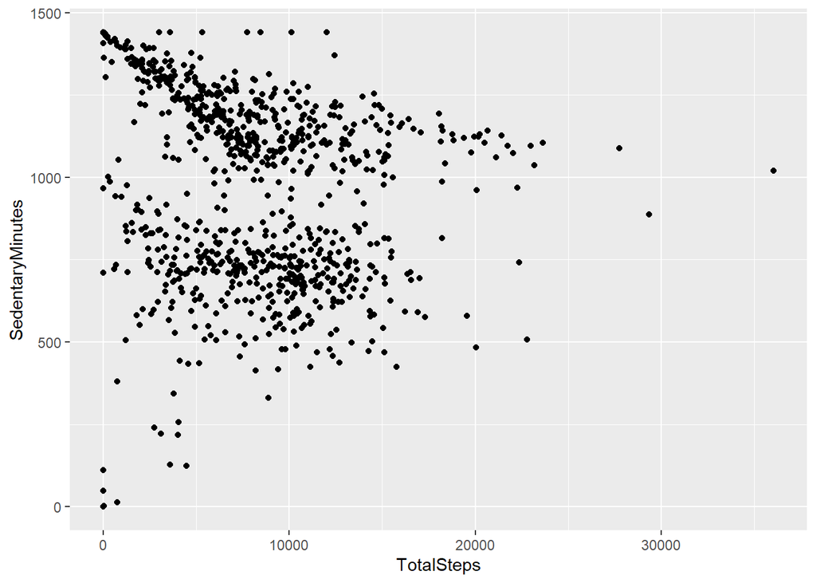

What’s the relationship between minutes asleep and time in bed? You might expect it to be almost completely linear - are there any unexpected trends?

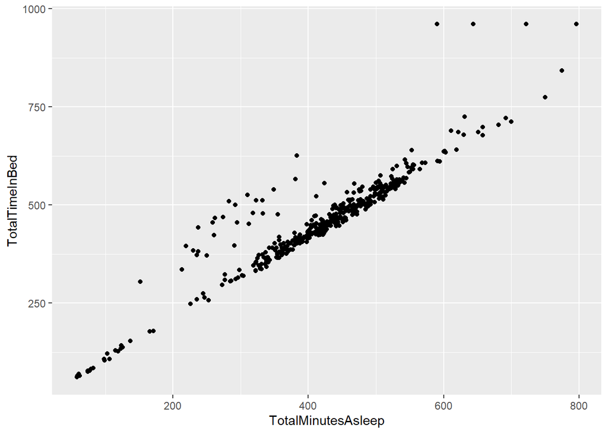

What could these trends tell you about how to help market this product? Or areas where you might want to explore further?

### Merging these two datasets together

```r
combined_data <- merge(sleepDay_merged, dailyActivity_merged, by="Id")
```

Take a look at how many participants are in this data set.

```r
n_distinct(combined_data$Id)
```

```
## [1] 24
```

Note that there were more participant Ids in the daily activity dataset that have been filtered out using merge. Consider using ‘outer_join’ to keep those in the dataset.

We first present the general trend of the users in the data. We will see that the application has a normally distributed user types. Moreover, the application helps users stay fit, and it handles intensities, METs, and calories consistently. We then investigate what affects usage. This is where we detected potential issues posed by the sleep data.

### General Trend

We first plot and compare the distributions of users’ average METs, intensities, and calories, using the daily_summary table. The average values are aggregated by the following code:

```r
intesities_summary <- daily_summary %>%
  group_by(Id) %>%
  summarise(average_calories = mean(Calories),
            average_intensities = mean(TotalIntensity),
            average_METs = mean(TotalMETs))
```

```r
calorie_distribution  <- intesities_summary  %>%
  select(Id, average_calories) %>%
    mutate(average_calories = case_when(
     average_calories <= 1500 ~ "<= 1500",
     average_calories <= 1800 & average_calories >1500 ~"1501 to 1800",
     average_calories <= 2100 & average_calories >1800 ~"1801 to 2100",
     average_calories <= 2400 & average_calories >2100 ~"2101 to 2400",
     average_calories <= 2700 & average_calories >2400 ~"2401 to 2700",
     average_calories <= 3000 & average_calories >2700 ~"2701 to 3000",
     average_calories <= 3300 & average_calories >3000 ~"3001 to 3300",
     average_calories > 3300 ~"X > 3300"
     )) %>%
  rename(range_calories = average_calories)

calorie_distribution  <- calorie_distribution  %>%
  group_by(range_calories)  %>%
  summarise(
    amount_Id = n(),
    percentage = amount_Id / 33 * 100)
```

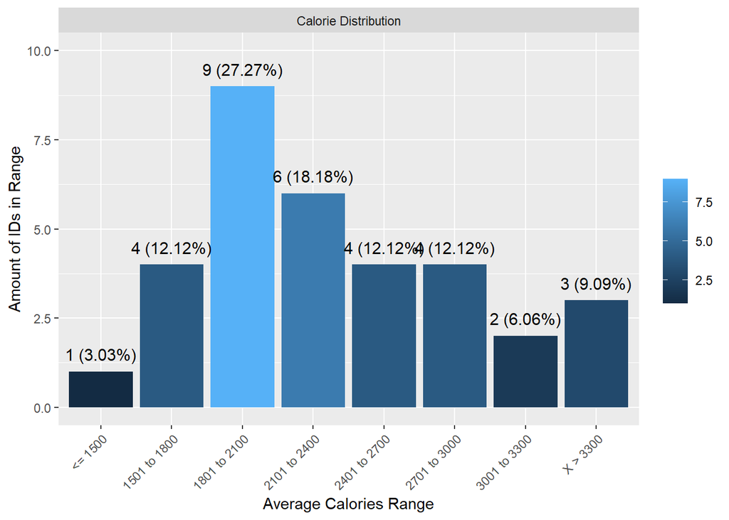

```r
intensity_distribution  <- intesities_summary  %>%
  select(Id, average_intensities) %>%
    mutate(average_intensities = case_when(
     average_intensities <= 100 ~ "<= 100",
     average_intensities <= 200 & average_intensities >100 ~"101 to 200",
     average_intensities <= 300 & average_intensities >200 ~"201 to 300",
     average_intensities <= 400 & average_intensities >300 ~"301 to 400",
     average_intensities > 400 ~"X > 400"
     )) %>%
  rename(range_intensities = average_intensities)

intensity_distribution  <- intensity_distribution  %>%
  group_by(range_intensities)  %>%
  summarise(
    amount_Id = n(),
    percentage = amount_Id / 33 * 100)
```

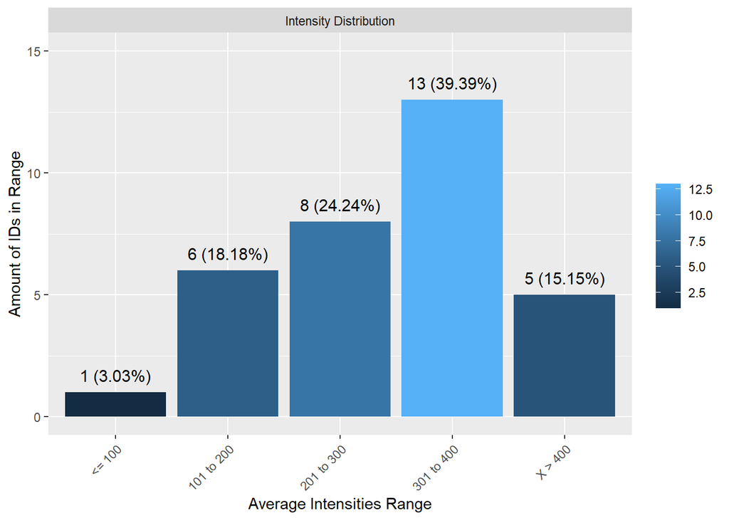

```r
METs_distribution  <- intesities_summary  %>%
  select(Id, average_METs) %>%
    mutate(average_METs = case_when(
     average_METs <= 18000 & average_METs >15000 ~"15,000 to 18,000",
     average_METs <= 21000 & average_METs >18000 ~"18,001 to 21,000",
     average_METs <= 24000 & average_METs >21000 ~"21,001 to 24,000",
     average_METs <= 27000 & average_METs >24000 ~"24,001 to 27,000",
     average_METs > 27000 ~"27,000 to 30,000"
     )) %>%
  rename(range_METs = average_METs)

METs_distribution  <- METs_distribution  %>%
  group_by(range_METs)  %>%
  summarise(
    amount_Id = n(),
    percentage = amount_Id / 33 * 100)
```

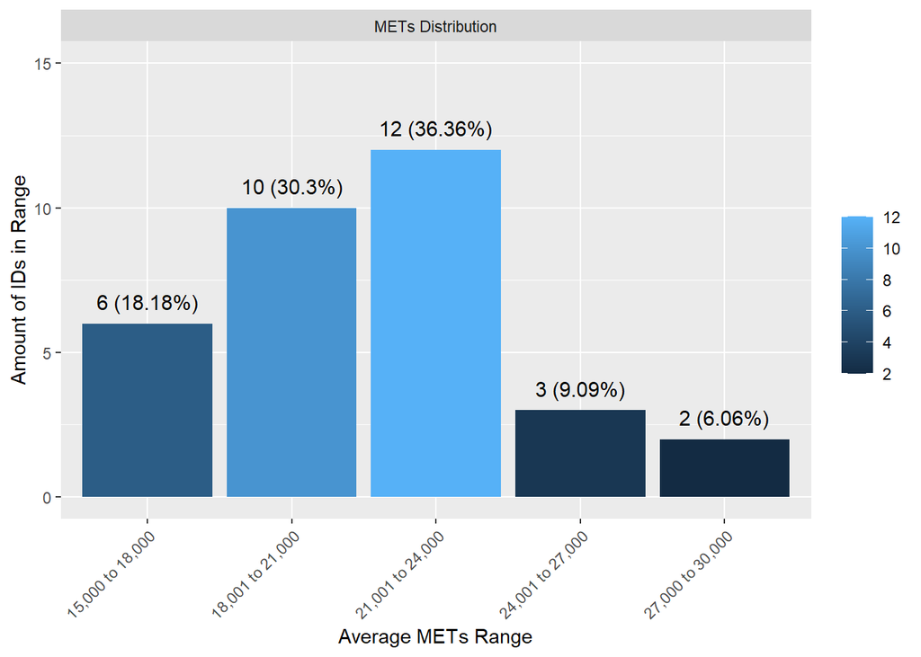

We see that the distributions are close to normal: they are mostly peaked in the middle and start to descend as we move away from the middle. This indicate that the application has a broad range of users. Next, we plot the trends over the recorded days by aggregating the daily_summary table.

### Calories, Intensities and METs Trends

```r
trends_daily_summary <- daily_summary %>%
  group_by(ActivityDate) %>%
  summarise(average_calories = mean(Calories),
            average_intensities = mean(TotalIntensity),
            average_METs = mean(TotalMETs))
```

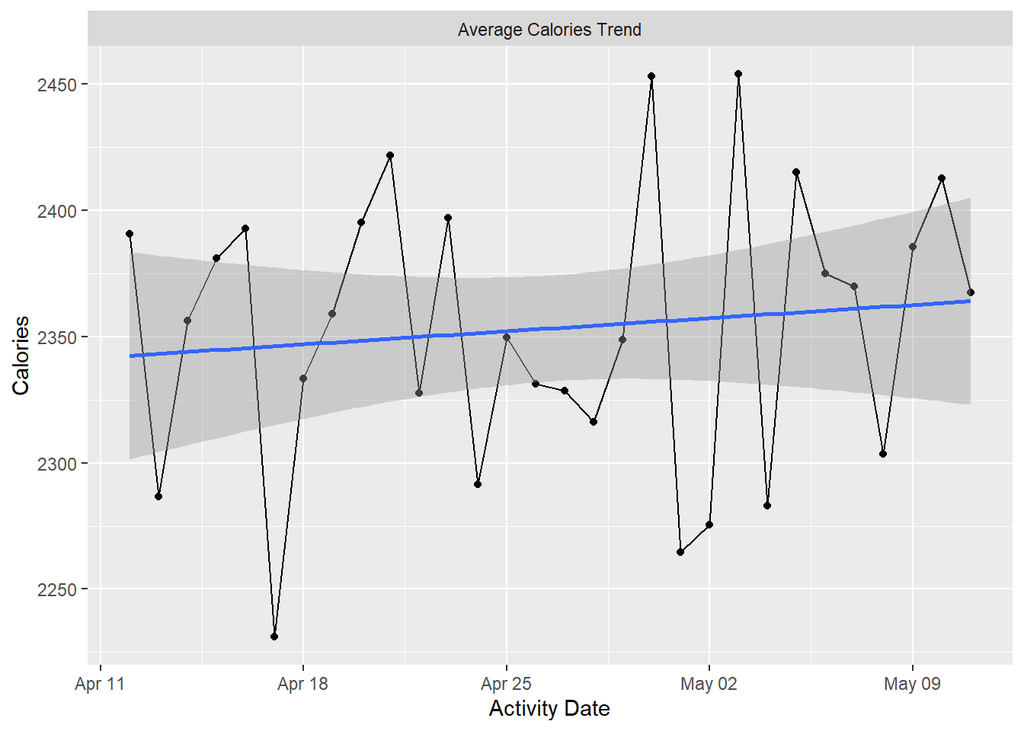

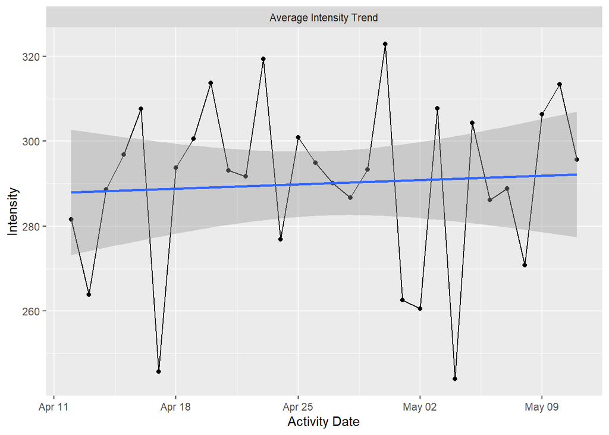

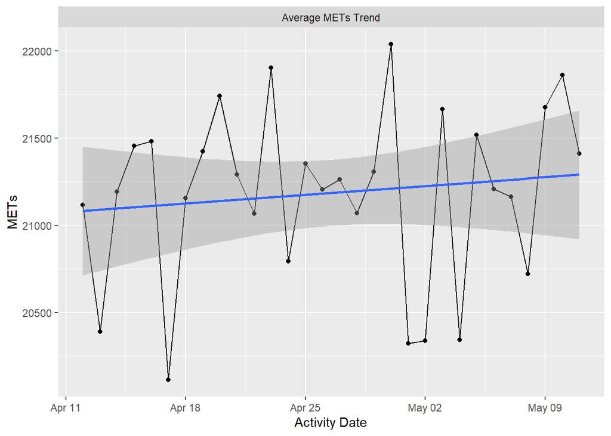

### Average intensity throughout a day

Next, we calculate and plot average minute intensities throughout the day, aggregated by all users. Doing so allows us to see which time period users tend to exercise or stay sedentary.

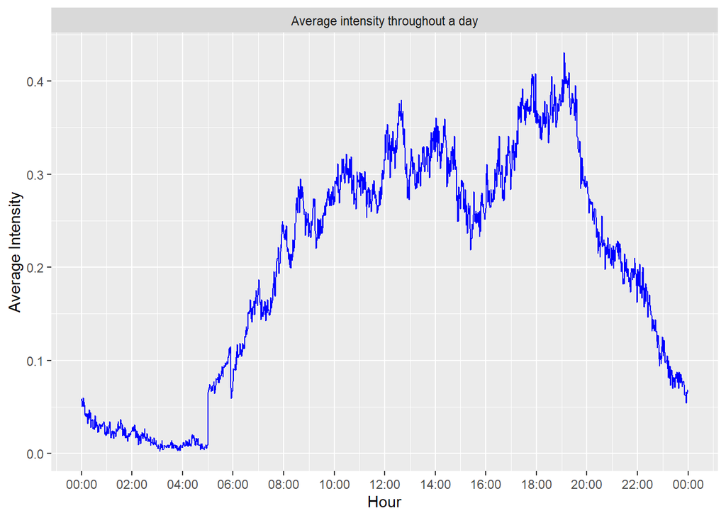

Average intensity throughout a day

We see that most people exercise after noon and the intensity peaked in the 17:00 - 20:00 window. This indicates that most users exercise after work. So far we have only looked at users’ exercises pattern. It is time to explore the sleep data.

### Sleep Patterns

We use the minuteSleep_merged table to aggregate and plot sleep start times:

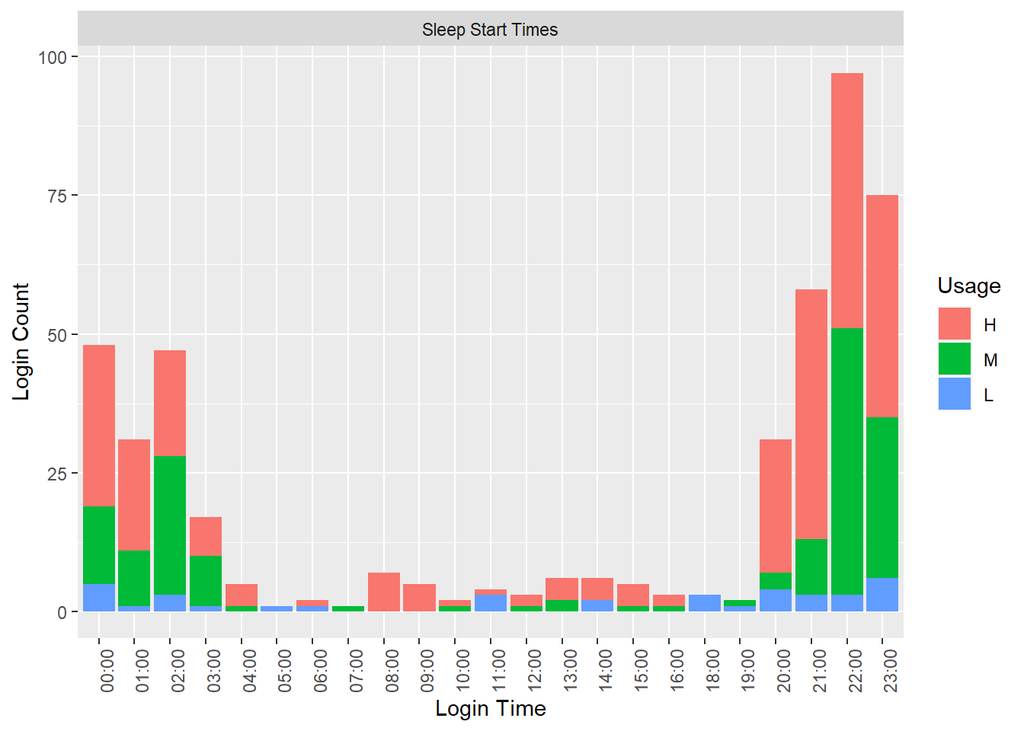

We do the same for sleep end times:

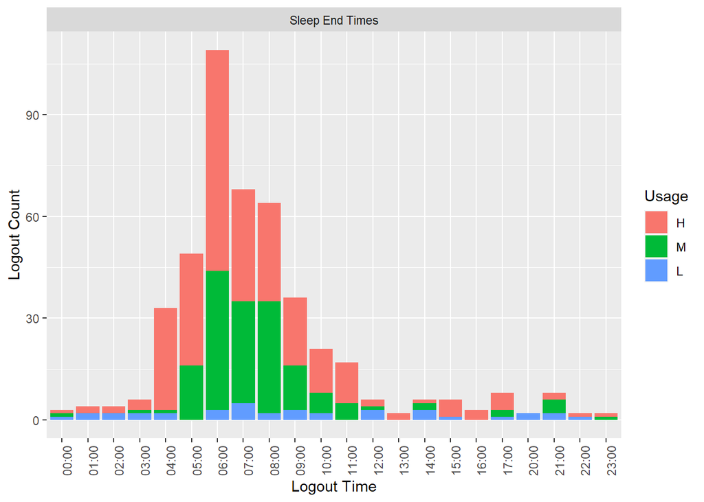

We see that most users wake up between 6 and 8 AM, and go to sleep around 10 to 11 PM. There are no major differences in sleep patterns among the H,M,L groups. So, what impacts usage frequency?

### What affects usage?

First, it is natural to guess users in the habit of more intense exercises tend to use the device more. we now demonstrate that indeed there is a moderate positive correlation between usage and overall workout intensities:

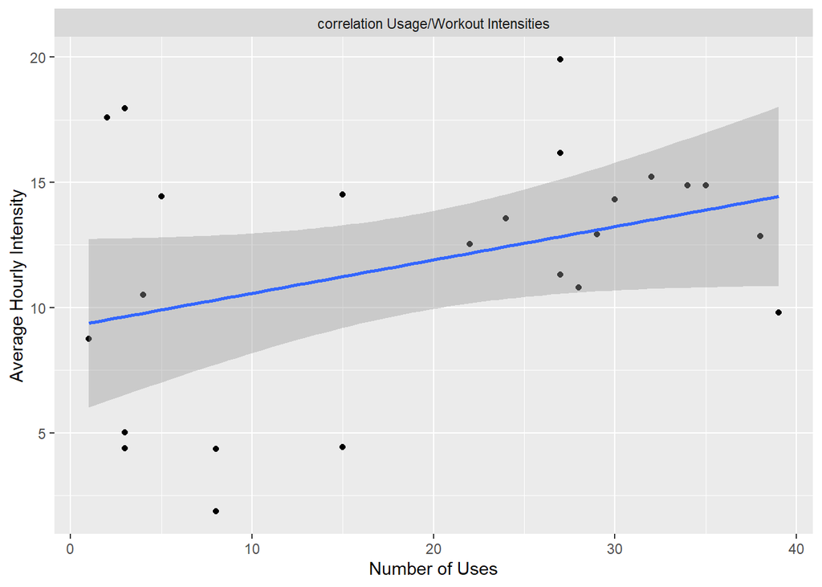

Next, we present a factor that influences user experience negatively.

### The discrepancy

Our discovery of the potential issues originated from the difficulty to interpret sleep values recorded in the dataset. Since there was no information about sleep values, we tried plotting the average minute sleep values throughout the day, aggregated by 24 users first:

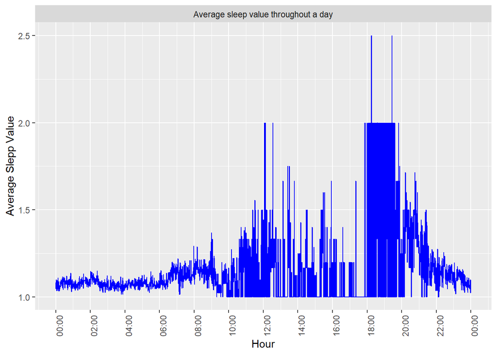

We were puzzled that the graph looks pretty similar to the intensity graph “Average intensity throughout a day” shown earlier. It is natural to guess the higher the sleep value, the less deep the sleep is. Nevertheless, the fact that the graph stretches throughout the entire day led us to believe that there may be instances where exercise intensities and sleep values were recorded simultaneously. We found out this is indeed the case:

```r
merge(x = minuteSleep_merged, y = minuteIntensities_merged, by.x = c("Id", "date"), by.y = c("Id","ActivityMinute")) %>%
  filter(Intensity>0) %>%
  as_tibble()
```

```
## # A tibble: 1,612 × 5
##            Id date                value       logId Intensity
##         <dbl> <chr>               <dbl>       <dbl>     <dbl>
##  1 1503960366 2016-04-15 05:18:00     2 11402722600         1
##  2 1503960366 2016-04-15 07:41:00     2 11402722600         1
##  3 1503960366 2016-04-15 08:07:00     2 11402722600         1
##  4 1503960366 2016-04-15 08:08:00     2 11402722600         1
##  5 1503960366 2016-04-15 08:17:00     2 11402722600         1
##  6 1503960366 2016-04-15 08:18:00     2 11402722600         1
##  7 1503960366 2016-04-15 08:19:00     2 11402722600         1
##  8 1503960366 2016-04-15 09:09:00     2 11402722600         1
##  9 1503960366 2016-04-15 09:10:00     2 11402722600         1
## 10 1503960366 2016-04-16 03:22:00     2 11421831252         1
## # ℹ 1,602 more rows
```

The query returned 1612 recording where both sleep value and intensity are not zero. We shall refer to these instances as discrepancies. Let us plot the correlation between usage and discrepancy.

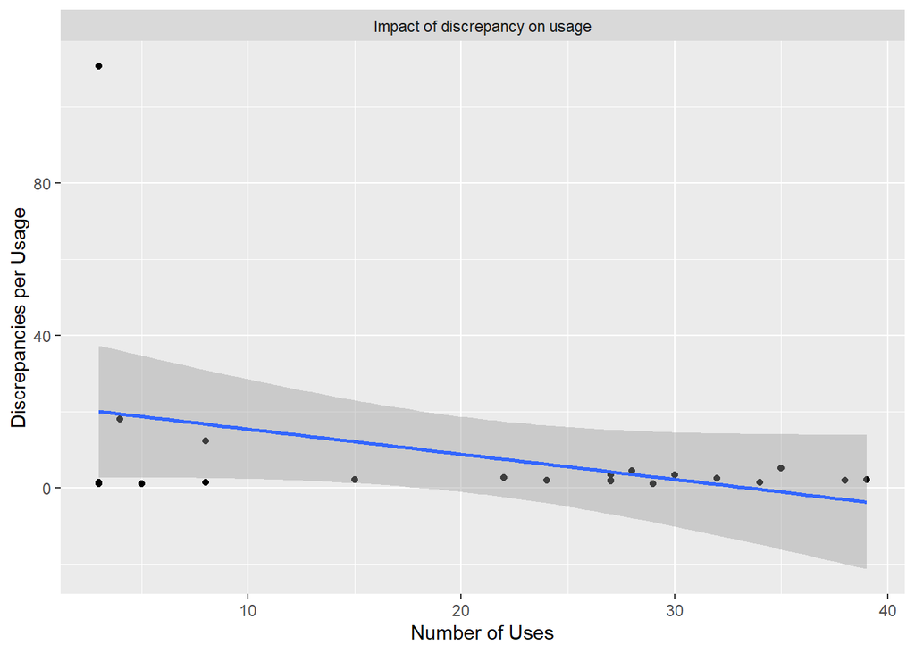

```r
minuteIntensities_merged %>%
  merge(y = minuteSleep_merged, by.x = c("Id","ActivityMinute"), by.y = c("Id", "date")) %>%
  filter(Intensity != 0) %>%
  group_by(Id) %>%
  summarise(disc = n()) %>% #aggregate each user's discrepancies
  merge(y = usage,by.y = "Id") %>%
  mutate(disc_per_usage = disc/num_of_use) %>%
  ggplot(aes(x = num_of_use, y = disc_per_usage)) +
  geom_point() +
  geom_smooth(method = lm) +
  xlab("Number of Uses") +
  ylab("Discrepancies per Usage") +
  facet_wrap(~"Impact of discrepancy on usage")
```

This indicates a negative impact of discrepancy on user experiences.

## **Recommended actions**

Overall the application successfully helped users maintain their fitness, and the different parameters such as calories, METs, and intensities were handled consistently. It was the sleep tracking function which we think needs some improvements.

The issues are mainly two. First and foremost, intensity should be given its context. Specifically intensities recorded during sleep should be distinguished from those recorded otherwise. There can still be a measure called total intensity that sums up to the two if preferable. Moreover, the application should also warn its users that the sleep tracking is on when they turn on the exercise tracking functions and vice versa. It is easy to foresee the frustration users have when they find the data report confusing or uninterpretable.

Second, to better track the trends of users’ sleep patterns, we think sleep tracking data should be generated similarly as intensities and METs data. METs and intensities are set at their base values when users are inactive. We found out that the sleep values were only recorded when the users log in. This could potentially skew the data when a user turns on the sleep device at an unusual time. For example, the following query:

```r
minuteSleep_merged %>%
  filter(strftime(date,
                  format = "%H:%m") <= '20:00' &
         strftime(date,
                  format = "%H:%m") >= '18:00') %>%
  distinct(Id)
```

```
## # A tibble: 4 × 1
##           Id
##        <dbl>
## 1 1644430081
## 2 5577150313
## 3 6117666160
## 4 8053475328
```

On the other hand, the following query:

```r
minuteIntensities_merged %>%
  filter(Intensity > 2 &
         strftime(ActivityMinute,
                  format = "%H:%m") >= '00:00' &
         strftime(ActivityMinute,
                  format = "%H:%m") <= '02:00') %>%
distinct(Id)
```

```
## # A tibble: 8 × 1
##           Id
##        <dbl>
## 1 1644430081
## 2 3977333714
## 3 4020332650
## 4 5577150313
## 5 6775888955
## 6 7086361926
## 7 8583815059
## 8 8792009665
```

confirmed there were high intensities (>=3) recorded during 12:00 AM - 2:00 AM period. Nevertheless, these instances did not produce spikes in the 24-hour intensity plot “Average intensity throughout a day” as they were neutralized by other users inactiveness recorded during this period.

Finally, we acknowledge that the idea to also record intensities while sleeping has its own merit. Doing so can detect potential health issues for the users. For example, the following queries:

```r
tmp <- minuteIntensities_merged %>%
  merge(y =
        minuteSleep_merged[-c(4)],
        by.x = c("Id", "ActivityMinute"),
        by.y = c("Id", "date")) %>%
  filter(Intensity > 2 &
         Id == "4020332650") %>%
  merge(y = minutes_heartrate,
        by.x = c("Id", "ActivityMinute"),
        by.y = c("Id", "time"))
```

```r
colnames(tmp) <- c("Id", "ActivityMinute", "ActivityIntensity", "SleepValue", "HeartRate")
tmp
```

```
##            Id      ActivityMinute ActivityIntensity SleepValue HeartRate
## 1  4020332650 2016-04-16 01:32:00                 3          1       134
## 2  4020332650 2016-04-16 01:33:00                 3          1       136
## 3  4020332650 2016-04-16 01:34:00                 3          1       136
## 4  4020332650 2016-04-16 01:35:00                 3          1       137
## 5  4020332650 2016-04-16 01:36:00                 3          1       136
## 6  4020332650 2016-04-16 01:37:00                 3          1       136
## 7  4020332650 2016-04-16 01:38:00                 3          1       136
## 8  4020332650 2016-04-16 01:39:00                 3          1       138
## 9  4020332650 2016-04-16 01:40:00                 3          1       138
## 10 4020332650 2016-04-16 01:41:00                 3          1       137
## 11 4020332650 2016-04-16 01:42:00                 3          1       133
## 12 4020332650 2016-04-16 01:43:00                 3          1       133
## 13 4020332650 2016-04-16 01:44:00                 3          1       132
## 14 4020332650 2016-04-16 01:45:00                 3          1       132
```

[output cut: 44 more lines]

```r
rm(tmp)
```

indicate that this very user has abnormally high heart rate during her sleep. We appreciate that the device can detect instances as these. The device will work even better if it handles intensities more carefully.

## **Final Thoughts**

The major findings in this study are the following:

We find the values assigned to the sleep records confusing. There is no clear indication if higher values means better sleep. On top of that, there are quite a few instances where both activity intensities and sleep values are detected simultaneously, resulting in possibly incorrect records. We refer to those instances as discrepancies. We will show that discrepancies have negative impact on user experience with discrepancy. Finally, we proposed ways for improving the sleep tracking function.